# 1_Practical

Ryan Greenup 17805315

12 March 2019

# Exercises (Part 1)

For `iris`, `heart` and `groceries` data sets:

1. Explore the variables
2. List the variables and classify as quantitative or qualitative
3. Provide a Research Question and identify a target variable
4. Identify whether or not this would exemplify supervised or unsupervised learning.

## `iris` Data Set

```r
iris <- read.csv(file = "Datasets/iris.csv", header = TRUE, sep = ",")
```

### (1) Explore the varibles

In order to explore the variables use `str()`, `summary()` and `head()`

```r
head(iris,4)
```

```
##   Type PW PL SW SL
## 1    0  2 14 33 50
## 2    1 24 56 31 67
## 3    1 23 51 31 69
## 4    0  2 10 36 46
```

```r
str(iris)
```

```
## 'data.frame':    150 obs. of  5 variables:
##  $ Type: int  0 1 1 0 1 1 2 2 1 2 ...
##  $ PW  : int  2 24 23 2 20 19 13 16 17 14 ...
##  $ PL  : int  14 56 51 10 52 51 45 47 45 47 ...
##  $ SW  : int  33 31 31 36 30 27 28 33 25 32 ...
##  $ SL  : int  50 67 69 46 65 58 57 63 49 70 ...
```

```r
summary(iris)
```

```
##       Type         PW              PL              SW
##  Min.   :0   Min.   : 1.00   Min.   :10.00   Min.   :20.00
##  1st Qu.:0   1st Qu.: 3.00   1st Qu.:16.00   1st Qu.:28.00
##  Median :1   Median :13.00   Median :44.00   Median :30.00
##  Mean   :1   Mean   :11.93   Mean   :37.79   Mean   :30.55
##  3rd Qu.:2   3rd Qu.:18.00   3rd Qu.:51.00   3rd Qu.:33.00
##  Max.   :2   Max.   :25.00   Max.   :69.00   Max.   :44.00
##        SL
##  Min.   :43.00
##  1st Qu.:51.00
##  Median :58.00
##  Mean   :58.45
##  3rd Qu.:64.00
##  Max.   :79.00
```

### (2) List the Variables

In this case the variables are:

| Variable Name | Type of Data | Measurement |
| --- | --- | --- |
| Type, (presumably species) | Categorical | The type of flower (i.e. species) |
| PW, (petal width) | Quantitative | Linear Distance |
| SW, (sepal width) | Quantitative | Linear Distance |
| PL, (petal length) | Quantitative | Linear Distance |
| SL, (sepal length) | Quantitative | Linear Distance |

### (3) provide a research Question

A possible research question could be:

- Can plant species be the Sepal Length and Petal Width.

### (4) Is this Supervised or Unsupervised Learning

This research question would be an example of **supervised learning** because the plant species are known and the model can be trained using already-known output values.

## `heart` dataset

```r
heart <- read.csv(file = "Datasets/heart.csv", header = TRUE, sep = ",")
```

### (1) Explore the varibles

In order to explore the variables use `str()`, `summary()` and `head()`

```r
head(heart,4)
```

```
##   X Age Sex    ChestPain RestBP Chol Fbs RestECG MaxHR ExAng Oldpeak Slope
## 1 1  63   1      typical    145  233   1       2   150     0     2.3     3
## 2 2  67   1 asymptomatic    160  286   0       2   108     1     1.5     2
## 3 3  67   1 asymptomatic    120  229   0       2   129     1     2.6     2
## 4 4  37   1   nonanginal    130  250   0       0   187     0     3.5     3
##   Ca       Thal AHD
## 1  0      fixed   0
## 2  3     normal   1
## 3  2 reversable   1
## 4  0     normal   0
```

```r
str(heart)
```

```
## 'data.frame':    303 obs. of  15 variables:
##  $ X        : int  1 2 3 4 5 6 7 8 9 10 ...
##  $ Age      : int  63 67 67 37 41 56 62 57 63 53 ...
##  $ Sex      : int  1 1 1 1 0 1 0 0 1 1 ...
##  $ ChestPain: Factor w/ 4 levels "asymptomatic",..: 4 1 1 2 3 3 1 1 1 1 ...
##  $ RestBP   : int  145 160 120 130 130 120 140 120 130 140 ...
##  $ Chol     : int  233 286 229 250 204 236 268 354 254 203 ...
##  $ Fbs      : int  1 0 0 0 0 0 0 0 0 1 ...
##  $ RestECG  : int  2 2 2 0 2 0 2 0 2 2 ...
##  $ MaxHR    : int  150 108 129 187 172 178 160 163 147 155 ...
##  $ ExAng    : int  0 1 1 0 0 0 0 1 0 1 ...
##  $ Oldpeak  : num  2.3 1.5 2.6 3.5 1.4 0.8 3.6 0.6 1.4 3.1 ...
##  $ Slope    : int  3 2 2 3 1 1 3 1 2 3 ...
##  $ Ca       : int  0 3 2 0 0 0 2 0 1 0 ...
##  $ Thal     : Factor w/ 3 levels "fixed","normal",..: 1 2 3 2 2 2 2 2 3 3 ...
##  $ AHD      : int  0 1 1 0 0 0 1 0 1 1 ...
```

```r
summary(heart)
```

```
##        X              Age             Sex                ChestPain
##  Min.   :  1.0   Min.   :29.00   Min.   :0.0000   asymptomatic:144
##  1st Qu.: 76.5   1st Qu.:48.00   1st Qu.:0.0000   nonanginal  : 86
##  Median :152.0   Median :56.00   Median :1.0000   nontypical  : 50
##  Mean   :152.0   Mean   :54.44   Mean   :0.6799   typical     : 23
##  3rd Qu.:227.5   3rd Qu.:61.00   3rd Qu.:1.0000
##  Max.   :303.0   Max.   :77.00   Max.   :1.0000
##
##      RestBP           Chol            Fbs            RestECG
##  Min.   : 94.0   Min.   :126.0   Min.   :0.0000   Min.   :0.0000
##  1st Qu.:120.0   1st Qu.:211.0   1st Qu.:0.0000   1st Qu.:0.0000
##  Median :130.0   Median :241.0   Median :0.0000   Median :1.0000
##  Mean   :131.7   Mean   :246.7   Mean   :0.1485   Mean   :0.9901
##  3rd Qu.:140.0   3rd Qu.:275.0   3rd Qu.:0.0000   3rd Qu.:2.0000
##  Max.   :200.0   Max.   :564.0   Max.   :1.0000   Max.   :2.0000
##
##      MaxHR           ExAng           Oldpeak         Slope
##  Min.   : 71.0   Min.   :0.0000   Min.   :0.00   Min.   :1.000
##  1st Qu.:133.5   1st Qu.:0.0000   1st Qu.:0.00   1st Qu.:1.000
##  Median :153.0   Median :0.0000   Median :0.80   Median :2.000
##  Mean   :149.6   Mean   :0.3267   Mean   :1.04   Mean   :1.601
##  3rd Qu.:166.0   3rd Qu.:1.0000   3rd Qu.:1.60   3rd Qu.:2.000
##  Max.   :202.0   Max.   :1.0000   Max.   :6.20   Max.   :3.000
##
##        Ca                 Thal          AHD
##  Min.   :0.0000   fixed     : 18   Min.   :0.0000
##  1st Qu.:0.0000   normal    :166   1st Qu.:0.0000
##  Median :0.0000   reversable:117   Median :0.0000
##  Mean   :0.6722   NA's      :  2   Mean   :0.4587
##  3rd Qu.:1.0000                    3rd Qu.:1.0000
##  Max.   :3.0000                    Max.   :1.0000
##  NA's   :4
```

### (2) List the Variables

In this case the variables are:

| Variable Name | Type of Data | Measurement |
| --- | --- | --- |
| X | Categorical ($\mathbb{N}$) | presumably observation number |
| Age | Quantitative | The age of the individual |
| Sex | Categorical | The individuals gender |
| Chestpain | Categorical | A classification of the type of chest pain |
| RestBP | Quantitative | A measurement of Sys. Blood Pressure at rest |
| Chol | Quantitative | Cholestrol levels |
| Fbs | Categorical | An indicator of whether or not Fasting Blood Sugar is above a threshold |
| RestECG | Categorical | An indicator of the type ECG result |
| MaxHR | Quantitative | A measurement of the maximum Heart Rate |
| ExAng | Categorical | An indicator of whether or not this individual suffered exercise induced angina |
| oldpeak | quantitative | A measurement of ECG change induced by exercise |
| slope | categorical | An indicator of the slope of the ST segment of an ECG graph |
| Ca | categorical (because it exists in $(\mathbb{N})$ | An indicator of how many of the three major blood vessels are revealed by fluroscopy |
| AHD | categorical | An indicator of whether or not the individual suffered Atherosclerotic Heart Disease |

### (3) provide a research Question

A possible research question could be:

- does MaxHR predict Atherosclerotic Heart Disease independent of age?

### (4) Is this Supervised or Unsupervised Learning

This research question would be an example of **supervised learning** because the incidence of AHD are known and the model can be trained using already-known output values.

## `groceries` dataset

```r
groceries <- read.csv(file = "Datasets/groceries(1).csv", header = TRUE, sep = ",")
```

### (1) Explore the varibles

In order to explore the variables use `str()`, `summary()` and `head()`

```r
head(groceries[,1:5], 4)
```

```
##   frankfurter sausage liver.loaf ham meat
## 1           0       0          0   0    0
## 2           0       0          0   0    0
## 3           0       0          0   0    0
## 4           0       0          0   0    0
```

```r
  #Restrict the columns of groceries to fit on the page
str(groceries[,1:5])
```

```
## 'data.frame':    9835 obs. of  5 variables:
##  $ frankfurter: int  0 0 0 0 0 0 0 0 0 0 ...
##  $ sausage    : int  0 0 0 0 0 0 0 0 0 0 ...
##  $ liver.loaf : int  0 0 0 0 0 0 0 0 0 0 ...
##  $ ham        : int  0 0 0 0 0 0 0 0 0 0 ...
##  $ meat       : int  0 0 0 0 0 0 0 0 0 0 ...
```

```r
summary(groceries[,1:5])
```

```
##   frankfurter         sausage          liver.loaf            ham
##  Min.   :0.00000   Min.   :0.00000   Min.   :0.000000   Min.   :0.00000
##  1st Qu.:0.00000   1st Qu.:0.00000   1st Qu.:0.000000   1st Qu.:0.00000
##  Median :0.00000   Median :0.00000   Median :0.000000   Median :0.00000
##  Mean   :0.05897   Mean   :0.09395   Mean   :0.005084   Mean   :0.02603
##  3rd Qu.:0.00000   3rd Qu.:0.00000   3rd Qu.:0.000000   3rd Qu.:0.00000
##  Max.   :1.00000   Max.   :1.00000   Max.   :1.000000   Max.   :1.00000
##       meat
##  Min.   :0.00000
##  1st Qu.:0.00000
##  Median :0.00000
##  Mean   :0.02583
##  3rd Qu.:0.00000
##  Max.   :1.00000
```

### (2) List the Variables

It is necessary to see whether or not the input value is 1/0 or a number, we can check this by doing:

```r
if(sum(groceries>1)==0){
  print("The values are Boolean")
} else{
  print("The values could be categorical or continuous")
}
```

```
## [1] "The values are Boolean"
```

In this case the variables are:

| Variable Name | Type of Data | Measurement |
| --- | --- | --- |
| food item | categorical | whether or not the item needs to be purchased |

The subsequent observations (rows) could represent the need for groceries at each week.

### (3) provide a research Question

A possible research question could be:

- Are certain food items more common at during holiday periods,
  - so for example is consumption of processed meats more common, this could be a public health enquiry.

### (4) Is this Supervised or Unsupervised Learning

This research question would be an example of **unsupervised learning** because the pattern of food consumption is not known and the algorithm must ‘learn’ what the patterns are.

# Exercises (Part 2)

## Advertising Data

### Import the Advertising Data

Import the Advertising Data:

```r
adv <- read.csv(file = "Datasets/Advertising(2).csv", header = TRUE, sep = ",")
```

### Explore and describe the data set

Use `head()` and `str()` to get an understanding of the data:

```r
head(adv)
```

```
##      TV Radio Newspaper Sales
## 1 230.1  37.8      69.2  22.1
## 2  44.5  39.3      45.1  10.4
## 3  17.2  45.9      69.3   9.3
## 4 151.5  41.3      58.5  18.5
## 5 180.8  10.8      58.4  12.9
## 6   8.7  48.9      75.0   7.2
```

```r
str(adv)
```

```
## 'data.frame':    200 obs. of  4 variables:
##  $ TV       : num  230.1 44.5 17.2 151.5 180.8 ...
##  $ Radio    : num  37.8 39.3 45.9 41.3 10.8 48.9 32.8 19.6 2.1 2.6 ...
##  $ Newspaper: num  69.2 45.1 69.3 58.5 58.4 75 23.5 11.6 1 21.2 ...
##  $ Sales    : num  22.1 10.4 9.3 18.5 12.9 7.2 11.8 13.2 4.8 10.6 ...
```

So it looks like some quantitative measurement related to advertising accross various genres, so let’s get a summary of it:

```r
summary(adv)
```

```
##        TV             Radio          Newspaper          Sales
##  Min.   :  0.70   Min.   : 0.000   Min.   :  0.30   Min.   : 1.60
##  1st Qu.: 74.38   1st Qu.: 9.975   1st Qu.: 12.75   1st Qu.:10.38
##  Median :149.75   Median :22.900   Median : 25.75   Median :12.90
##  Mean   :147.04   Mean   :23.264   Mean   : 30.55   Mean   :14.02
##  3rd Qu.:218.82   3rd Qu.:36.525   3rd Qu.: 45.10   3rd Qu.:17.40
##  Max.   :296.40   Max.   :49.600   Max.   :114.00   Max.   :27.00
```

### Create Scatter Plots of the Data

#### First consider all possible correlations using `corrplot`

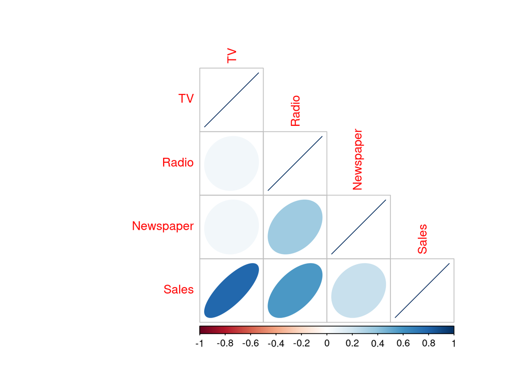

```r
cormatadv <- cor(adv)
corrplot(method = 'ellipse', type = 'lower', corr = cormatadv)
```

looking at this plot it appears that TV is most correlated with sales:

#### Sales vs TV Advertising

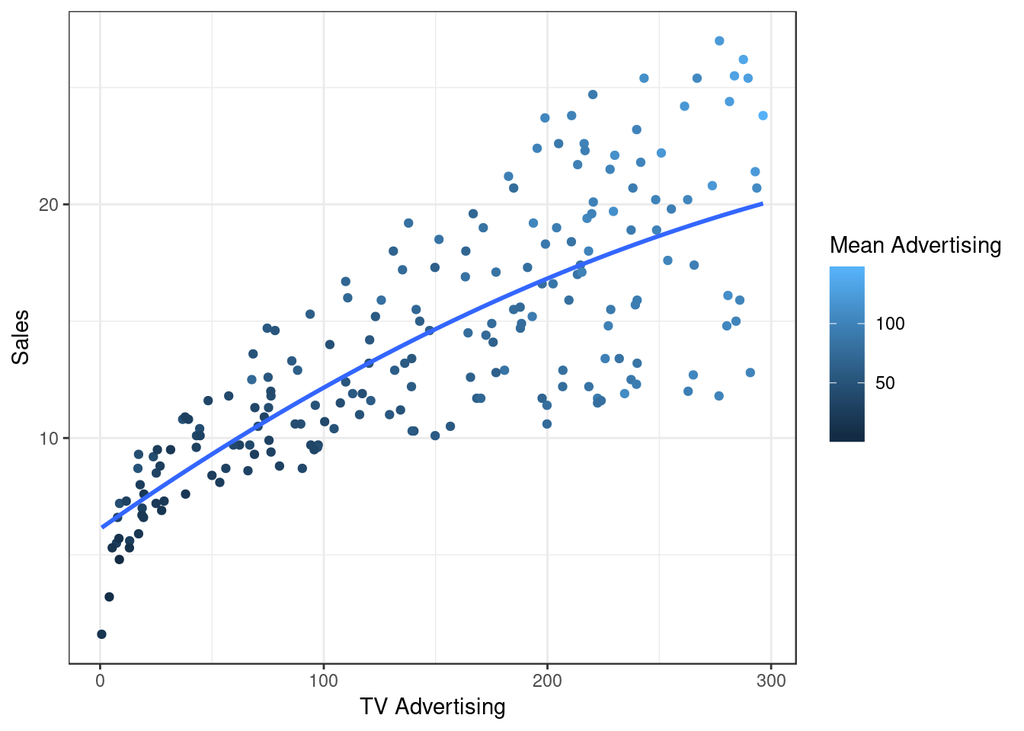

```r
adv$MeanAdvertising <- rowMeans(adv[,c(!(names(adv) == "Sales"))])

ggplot(data = adv, aes(x = TV, y = Sales, col = MeanAdvertising)) +
  geom_point() +
  theme_bw() +
  stat_smooth(method = 'lm', formula = y ~ poly(x, 2, raw = TRUE), se = FALSE) +
 # stat_smooth(method = 'lm', formula = y ~ log(x), se = FALSE) +
  labs(col = "Mean Advertising", x= "TV Advertising")
```

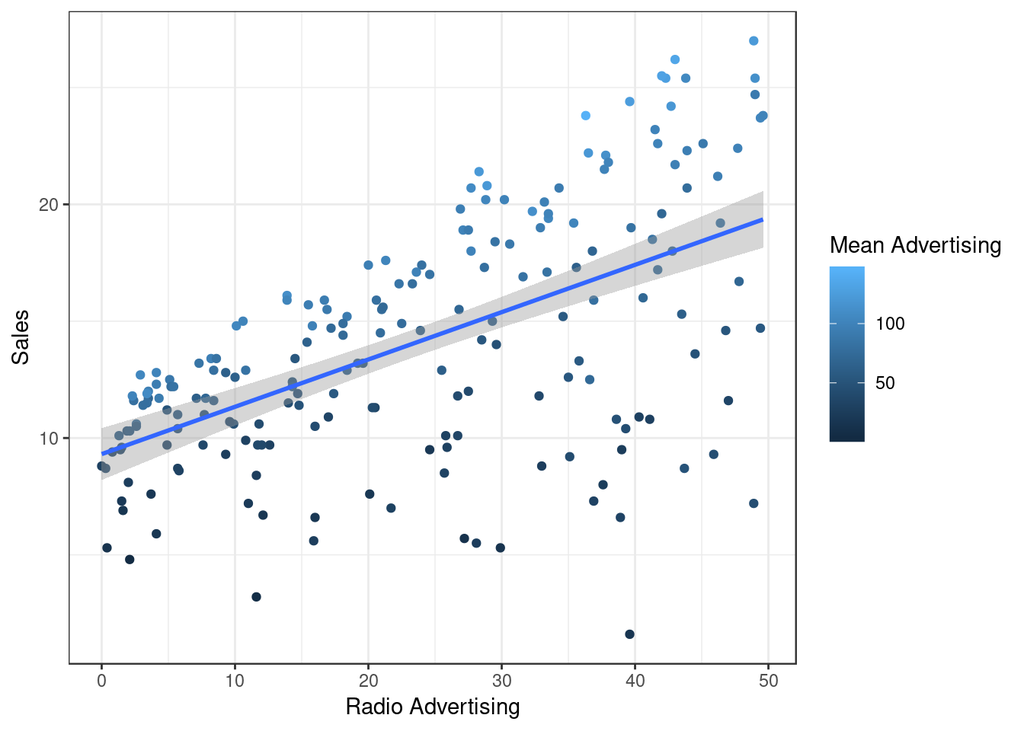

```r
 ggplot(data = adv, aes(x = Radio, y = Sales, col = MeanAdvertising)) +
   geom_point() +
   theme_bw() +
   labs(col = "Mean Advertising", x= "Radio Advertising") +
   geom_smooth(method = 'lm')
```

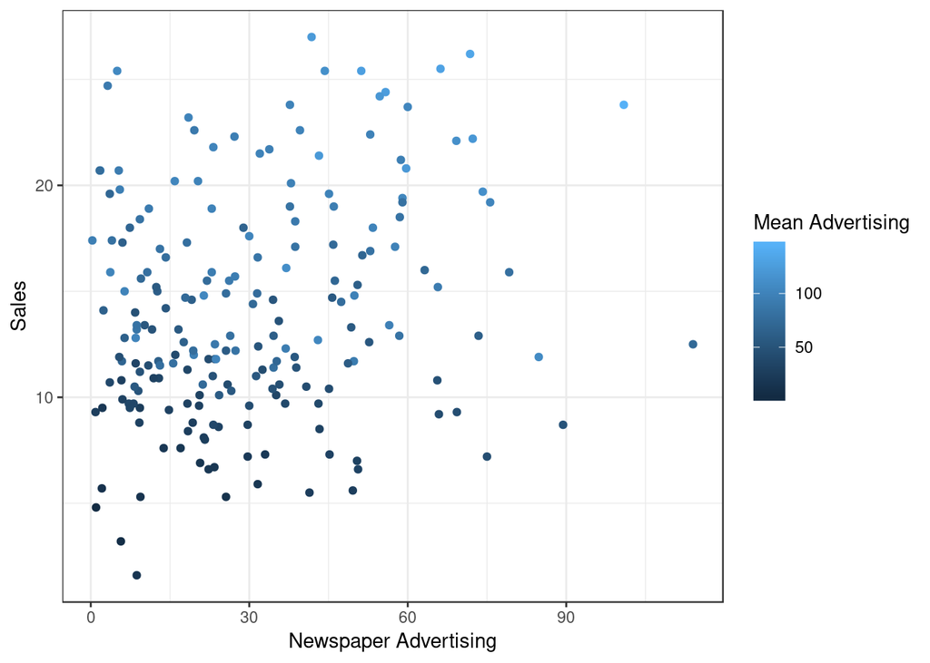

```r
padv <- ggplot(data = adv, aes(x = Newspaper, y = Sales, col = MeanAdvertising)) +
  geom_point() +
  theme_bw() +
  labs(col = "Mean Advertising", x= "Newspaper Advertising")

padv
```

```r
#Thise could be combined into an interactive graph by wrapping in ggplotly(padv)
```

## iris Data

### Import the iris Data

The iris data has alread been imported and assigned the variable `iris`.

### Explore and describe the data set

The iris data set can be explored using `head()` and `str()`

```r
head(iris)
```

```
##   Type PW PL SW SL
## 1    0  2 14 33 50
## 2    1 24 56 31 67
## 3    1 23 51 31 69
## 4    0  2 10 36 46
## 5    1 20 52 30 65
## 6    1 19 51 27 58
```

```r
str(iris)
```

```
## 'data.frame':    150 obs. of  5 variables:
##  $ Type: int  0 1 1 0 1 1 2 2 1 2 ...
##  $ PW  : int  2 24 23 2 20 19 13 16 17 14 ...
##  $ PL  : int  14 56 51 10 52 51 45 47 45 47 ...
##  $ SW  : int  33 31 31 36 30 27 28 33 25 32 ...
##  $ SL  : int  50 67 69 46 65 58 57 63 49 70 ...
```

The data set can be described using the `summary()` function

```r
summary(iris)
```

```
##       Type         PW              PL              SW
##  Min.   :0   Min.   : 1.00   Min.   :10.00   Min.   :20.00
##  1st Qu.:0   1st Qu.: 3.00   1st Qu.:16.00   1st Qu.:28.00
##  Median :1   Median :13.00   Median :44.00   Median :30.00
##  Mean   :1   Mean   :11.93   Mean   :37.79   Mean   :30.55
##  3rd Qu.:2   3rd Qu.:18.00   3rd Qu.:51.00   3rd Qu.:33.00
##  Max.   :2   Max.   :25.00   Max.   :69.00   Max.   :44.00
##        SL
##  Min.   :43.00
##  1st Qu.:51.00
##  Median :58.00
##  Mean   :58.45
##  3rd Qu.:64.00
##  Max.   :79.00
```

### Create Scatter Plots of the Data

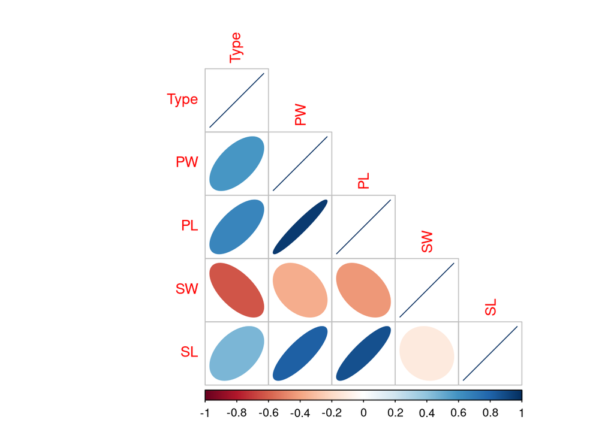

```r
coriris <- cor(iris[,!(names(iris) == "Species")])
corrplot(method = 'ellipse', type = 'lower', corr = coriris)
```

because sepal width and sepal length appear to be the most independent we will create a linear regression of those variables:

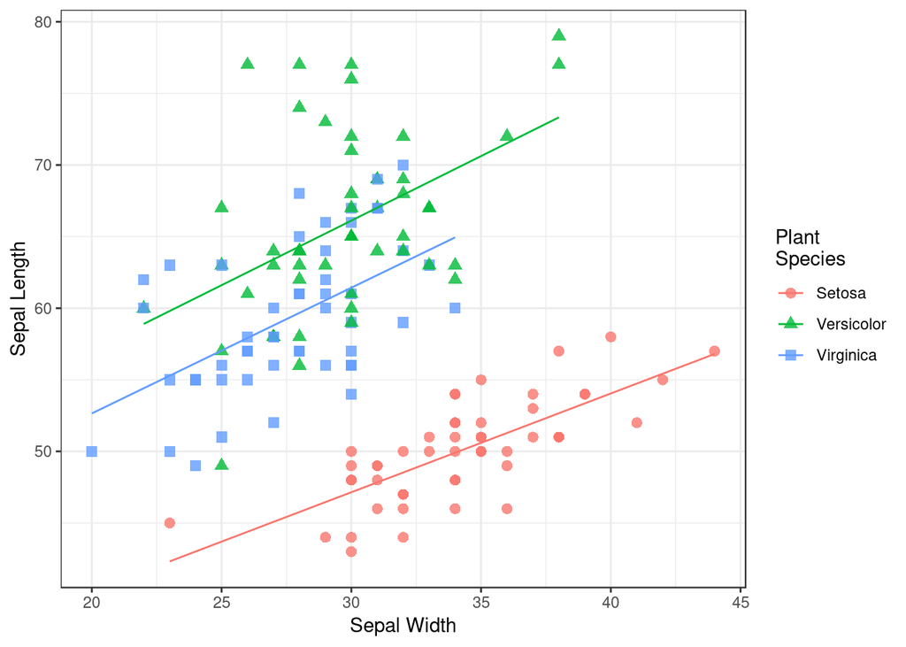

```r
#Make the datatype a factor
iris$Type <- as.factor(iris$Type)

 ggplot(data = iris, aes(x = SW, y = SL, col = Type, shape = Type)) +
   geom_point(size = 2.5, alpha = 0.8) +
   theme_bw() +
   labs(col = "Plant Species", shape= "Plant\nSpecies", x = "Sepal Width", y = "Sepal Length") +
   geom_smooth(method = 'lm', se = FALSE, lwd = 0.5) +
   # It is necessary to use scale_shape_discrete in order to change the labels:
      #make sure the names match, if the legend names match, they'll be merged.
   scale_shape_discrete(name  ="Plant\nSpecies",
                           breaks=c("0", "1", "2"),
                           labels=c("Setosa", "Versicolor", "Virginica")) +
   scale_color_discrete(name  ="Plant\nSpecies",
                           breaks=c("0", "1", "2"),
                           labels=c("Setosa", "Versicolor", "Virginica"))
```

```r
  # This could have also been done with the built in iris data set, that was where I got the legend labels from
```